# Second-Year Paper

Nicolas Restrepo

10/30/2019

## What is “weird” about harmless wrongs?

### Research Question

How can Affect Control Theory’s formal approach to meaning help us understand how different types of moral transgressions are interpreted?

### Motivation

Social scientists interested in morality have often resorted to the use of fictional scenarios in order to examine moral judgment. Longstanding research traditions have created large repositories of such vignettes and a great deal of our current knowledge about moral cognition has been built on this technique. These fictional scenarios tend to share a grammatical structure (actor-behavior-object) which is, incidentally, the main unit of analysis of Affect Control Theory (ACT). In this project, we seek to take advantage of this common ground in order to explore whether the formal properties of moral transgressions shape the ways in which they are interpreted.

The underlying structure of most moral vignettes allows us to “translate” them into the mathematical language of ACT. This, in turn, provides additional information about the semantic properties of these scenarios: the meanings we attach to the actors and objects, and the overall unexpectedness of each event (what Affect Control Theory calls “deflection”). We have reviewed the literature on moral vignettes and have translated 25 events into the form of ACT. The following figure shows the events and their corresponding deflections:

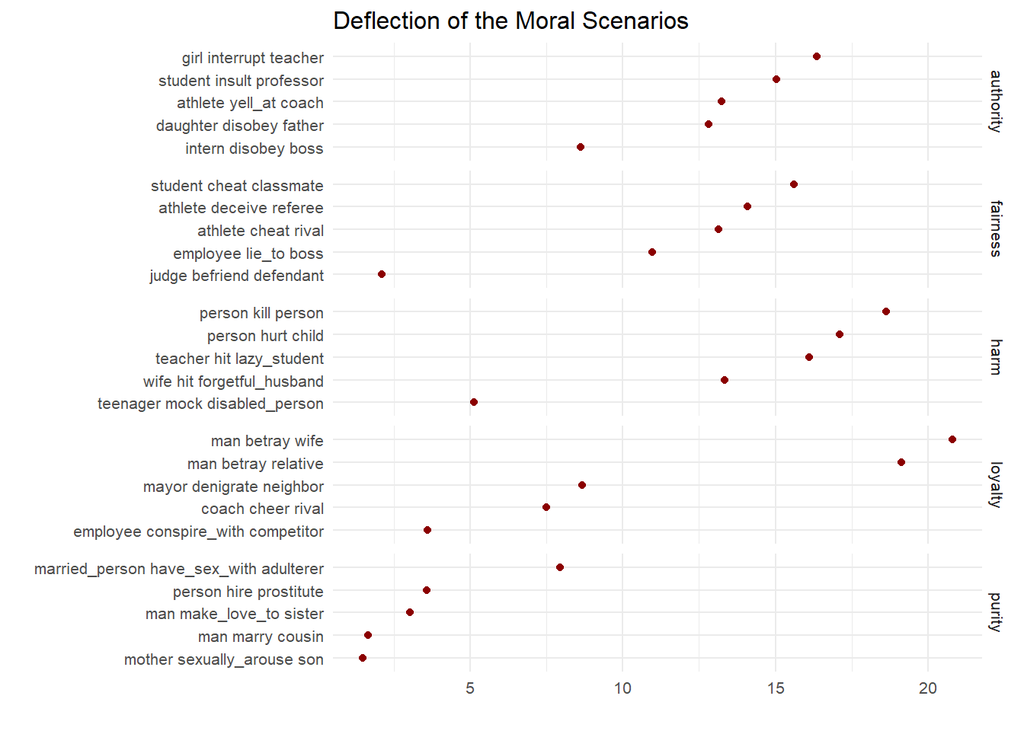

At first glance, we notice something odd: while deflection is a good predictor of moral wrongdoing for certain events (such as murder), it really misses the mark on scenarios that involve the transgression of social norms (such as incest). Within the framework of ACT, a man marrying his cousin or two siblings having sex are totally mundane events.

This is particularly puzzling given previous work on moral psychology, which suggests that transgressions that involve taboos are generally considered more atypical. Although actions that involve harm are reliably categorized as more immoral than the breaching of taboos, the latter are consistently perceived as “weirder”. This seems to contradict what our translations suggest.

However, rather than a dent on ACT’s framework, this could be interpreted as an insight about how different kinds of moral transgressions are interpreted. Let’s take two concrete examples:

- A man murders his brother
- A man marries his cousin

The fundamental difference between both statements is that the “wrongness” of the first one lies within the semantic structure of the sentence, while the “wrongness” of the latter lies outside the predicate itself, in our social norms about incest. Try replacing the subjects in the first sentence and you will almost invariably end up with an immoral situation; a man murdering a stranger might seem less shocking but no less immoral. The same exercise does not work for the second event: both identities have to be very specific for the event to be immoral. The “wrongness” of the vignette is not a property of the event itself but of the social norms we imprint upon it. In this study, we seek to tease out this difference, exploring whether ACT’s formal approach to meaning can help us understand how harmful and harmless wrongs are judged differently.

### Research Plan

This is a two-part study. In the first survey, we will provide participants (n = 200) with a list of 25 moral vignettes and we will ask them about the extent to which they consider each scenario harmful, immoral, and unexpected. The main goal, at this point, is to examine whether the moral scenarios, when translated into the format of Affect Control Theory, are still interpreted consistently. Here, it is key to confirm that established results can be reproduced using this new format. If this is the case, then this would open new avenues for research, allowing us to explore how the underlying structures of meaning of moral scenarios affect the ways in which they are interpreted.

In the second survey, we will present participants with the same vignettes and ask them to categorize them as either harmless/harmful, not immoral/immoral, and expected/unexpected. They will categorize each event using their keyboards. This last detail is important because reaction time will be the key dependent variable in this case. We hypothesize that the time it will take a respondent to categorize an event will be related to the scenario’s “deflection”. However, we also expect that this relationship will vary depending on the type of moral transgression that is being represented. Thus, if it is true that individuals must imprint social norms in order to decipher the “wrongness” of certain scenarios, it is plausible to conjecture that it will take them longer to categorize these vignettes. This research design, then, will help analyze whether different kinds of moral transgressions, given their formal semantic properties, require more or less cognitive effort to interpret.